# Project: Wrangle and Analyze Data

## Gathering Data

```python
# import libraries
import pandas as pd
import requests
import json
import numpy as np
import tweepy
import matplotlib.pyplot as plt
from IPython.display import Image
import seaborn as sns
%matplotlib inline
```

```python
# read csv file provided by Udacity
twitter_archive_df = pd.read_csv('twitter-archive-enhanced.csv')
```

```python
twitter_archive_df.head()
```

|  | tweet_id | in_reply_to_status_id | in_reply_to_user_id | timestamp | source | text | retweeted_status_id | retweeted_status_user_id | retweeted_status_timestamp | expanded_urls | rating_numerator | rating_denominator | name | doggo | floofer | pupper | puppo |
| --- | --- | --- | --- | --- | --- | --- | --- | --- | --- | --- | --- | --- | --- | --- | --- | --- | --- |
| 0 | 892420643555336193 | NaN | NaN | 2017-08-01 16:23:56 +0000 | <a href="http://twitter.com/download/iphone" r... | This is Phineas. He's a mystical boy. Only eve... | NaN | NaN | NaN | https://twitter.com/dog_rates/status/892420643... | 13 | 10 | Phineas | None | None | None | None |
| 1 | 892177421306343426 | NaN | NaN | 2017-08-01 00:17:27 +0000 | <a href="http://twitter.com/download/iphone" r... | This is Tilly. She's just checking pup on you.... | NaN | NaN | NaN | https://twitter.com/dog_rates/status/892177421... | 13 | 10 | Tilly | None | None | None | None |
| 2 | 891815181378084864 | NaN | NaN | 2017-07-31 00:18:03 +0000 | <a href="http://twitter.com/download/iphone" r... | This is Archie. He is a rare Norwegian Pouncin... | NaN | NaN | NaN | https://twitter.com/dog_rates/status/891815181... | 12 | 10 | Archie | None | None | None | None |
| 3 | 891689557279858688 | NaN | NaN | 2017-07-30 15:58:51 +0000 | <a href="http://twitter.com/download/iphone" r... | This is Darla. She commenced a snooze mid meal... | NaN | NaN | NaN | https://twitter.com/dog_rates/status/891689557... | 13 | 10 | Darla | None | None | None | None |
| 4 | 891327558926688256 | NaN | NaN | 2017-07-29 16:00:24 +0000 | <a href="http://twitter.com/download/iphone" r... | This is Franklin. He would like you to stop ca... | NaN | NaN | NaN | https://twitter.com/dog_rates/status/891327558... | 12 | 10 | Franklin | None | None | None | None |

```python
# downloading tweet image predictions from Udacity
tweet_image_prediction_url = "https://d17h27t6h515a5.cloudfront.net/topher/2017/August/599fd2ad_image-predictions/image-predictions.tsv"
response = requests.get(tweet_image_prediction_url)
with open('image-predictions.tsv', mode ='wb') as file:
    file.write(response.content)
```

```python
# read tsv file provided by Udacity
prediction_df = pd.read_csv('image-predictions.tsv', sep='\t' )
prediction_df.head()
```

|  | tweet_id | jpg_url | img_num | p1 | p1_conf | p1_dog | p2 | p2_conf | p2_dog | p3 | p3_conf | p3_dog |
| --- | --- | --- | --- | --- | --- | --- | --- | --- | --- | --- | --- | --- |
| 0 | 666020888022790149 | https://pbs.twimg.com/media/CT4udn0WwAA0aMy.jpg | 1 | Welsh_springer_spaniel | 0.465074 | True | collie | 0.156665 | True | Shetland_sheepdog | 0.061428 | True |
| 1 | 666029285002620928 | https://pbs.twimg.com/media/CT42GRgUYAA5iDo.jpg | 1 | redbone | 0.506826 | True | miniature_pinscher | 0.074192 | True | Rhodesian_ridgeback | 0.072010 | True |
| 2 | 666033412701032449 | https://pbs.twimg.com/media/CT4521TWwAEvMyu.jpg | 1 | German_shepherd | 0.596461 | True | malinois | 0.138584 | True | bloodhound | 0.116197 | True |
| 3 | 666044226329800704 | https://pbs.twimg.com/media/CT5Dr8HUEAA-lEu.jpg | 1 | Rhodesian_ridgeback | 0.408143 | True | redbone | 0.360687 | True | miniature_pinscher | 0.222752 | True |
| 4 | 666049248165822465 | https://pbs.twimg.com/media/CT5IQmsXIAAKY4A.jpg | 1 | miniature_pinscher | 0.560311 | True | Rottweiler | 0.243682 | True | Doberman | 0.154629 | True |

The cells belove are intentionally commented out to disble to run the long running api request.

```python
# create API object / code was given
#consumer_key = 'qFsjmwCgzV1w51Ep9D6VvNUMU'
#consumer_secret = 'THK6rnst4JA3V06hH1tmVcNx4TkzlhroegQGlnvSqxYWQaQJRS'
#access_token = '2503839792-kFTlLGop9X6JSJmAdFUPlxwpxvBaHw8BmFgq07C'
#access_secret = 'pHvKl2bOXTdlKw0dhK74QleNWir2AFyESkbCH3CAMw5Nr'

#auth = tweepy.OAuthHandler(consumer_key, consumer_secret)
#auth.set_access_token(access_token, access_secret)

#api = tweepy.API(auth)
```

```python
# valid api data list
#tweets = []
# error list
#error_tweets = []
# loop trough by tweet_id
#for tweet_id in twitter_archive_df['tweet_id']:
#    try:
#        tweet_json = api.get_status(tweet_id,
#                                    wait_on_rate_limit=True,
#                                    wait_on_rate_limit_notify=True)._json
#        tweets.append(tweet_json)
#
#    except BaseException as e:
#        error_tweets.append({'tweet_id': str(tweet_id),
#                             'tweet_error': str(e)
#                            })
```

```python
# number of valid tweets
#len(tweets)
```

```python
# list error tweets
#error_tweets
```

```python
# write tweets data to tweet_json.txt
#with open('tweet_json.txt', 'w', encoding = 'utf-8') as json_file:
#    json.dump(tweets, json_file)
```

```python
# make dataframe from json data
json_df = pd.read_json('tweet_json.txt')
json_df = json_df[['id', 'retweet_count', 'favorite_count']]
json_df.head()
```

|  | id | retweet_count | favorite_count |
| --- | --- | --- | --- |
| 0 | 892420643555336193 | 8378 | 38258 |
| 1 | 892177421306343426 | 6185 | 32795 |
| 2 | 891815181378084864 | 4092 | 24698 |
| 3 | 891689557279858688 | 8520 | 41580 |
| 4 | 891327558926688256 | 9229 | 39760 |

## Asses Data

Dataframes to asses:

- twitter_archive_df
- prediction_df
- json_df

### Asses data from twitter-archive-enhanced.csv - twitter_archive_df

```python
twitter_archive_df.info()
```

```
<class 'pandas.core.frame.DataFrame'>
RangeIndex: 2356 entries, 0 to 2355
Data columns (total 17 columns):
tweet_id                      2356 non-null int64
in_reply_to_status_id         78 non-null float64
in_reply_to_user_id           78 non-null float64
timestamp                     2356 non-null object
source                        2356 non-null object
text                          2356 non-null object
retweeted_status_id           181 non-null float64
retweeted_status_user_id      181 non-null float64
retweeted_status_timestamp    181 non-null object
expanded_urls                 2297 non-null object
rating_numerator              2356 non-null int64
rating_denominator            2356 non-null int64
name                          2356 non-null object
doggo                         2356 non-null object
floofer                       2356 non-null object
pupper                        2356 non-null object
puppo                         2356 non-null object
dtypes: float64(4), int64(3), object(10)
memory usage: 313.0+ KB
```

There are 2356 entries.  
Some columns have missing data.  
There are retweets in the data.  
Time related columns arent timestamp datatype.

```python
sum(twitter_archive_df.duplicated())
```

```
0
```

```python
twitter_archive_df['tweet_id'].duplicated().sum()
```

```
0
```

There are no duplicated rows.

```python
twitter_archive_df.sample(10)
```

|  | tweet_id | in_reply_to_status_id | in_reply_to_user_id | timestamp | source | text | retweeted_status_id | retweeted_status_user_id | retweeted_status_timestamp | expanded_urls | rating_numerator | rating_denominator | name | doggo | floofer | pupper | puppo |
| --- | --- | --- | --- | --- | --- | --- | --- | --- | --- | --- | --- | --- | --- | --- | --- | --- | --- |
| 282 | 839239871831150596 | NaN | NaN | 2017-03-07 22:22:32 +0000 | <a href="http://twitter.com/download/iphone" r... | This is Odie. He's big. 13/10 would attempt to... | NaN | NaN | NaN | https://twitter.com/dog_rates/status/839239871... | 13 | 10 | Odie | None | None | None | None |
| 945 | 752660715232722944 | NaN | NaN | 2016-07-12 00:27:52 +0000 | <a href="http://twitter.com/download/iphone" r... | Hooman used Pokeball\n*wiggle*\n*wiggle*\nDogg... | NaN | NaN | NaN | https://twitter.com/dog_rates/status/752660715... | 10 | 10 | None | doggo | None | None | None |
| 556 | 803638050916102144 | NaN | NaN | 2016-11-29 16:33:36 +0000 | <a href="http://twitter.com/download/iphone" r... | Pupper hath acquire enemy. 13/10 https://t.co/... | NaN | NaN | NaN | https://twitter.com/dog_rates/status/803638050... | 13 | 10 | None | None | None | pupper | None |
| 1550 | 689154315265683456 | NaN | NaN | 2016-01-18 18:36:07 +0000 | <a href="http://twitter.com/download/iphone" r... | We normally don't rate birds but I feel bad co... | NaN | NaN | NaN | https://twitter.com/dog_rates/status/689154315... | 9 | 10 | None | None | None | None | None |
| 1951 | 673686845050527744 | NaN | NaN | 2015-12-07 02:13:55 +0000 | <a href="http://twitter.com/download/iphone" r... | This is George. He's upset that the 4th of Jul... | NaN | NaN | NaN | https://twitter.com/dog_rates/status/673686845... | 11 | 10 | George | None | None | None | None |
| 70 | 879008229531029506 | NaN | NaN | 2017-06-25 16:07:47 +0000 | <a href="http://twitter.com/download/iphone" r... | This is Beau. That is Beau's balloon. He takes... | NaN | NaN | NaN | https://twitter.com/dog_rates/status/879008229... | 13 | 10 | Beau | None | None | None | None |
| 233 | 847842811428974592 | NaN | NaN | 2017-03-31 16:07:33 +0000 | <a href="http://twitter.com/download/iphone" r... | This is Rontu. He is described as a pal, cuddl... | NaN | NaN | NaN | https://www.gofundme.com/help-save-rontu,https... | 12 | 10 | Rontu | None | None | None | None |
| 113 | 870726314365509632 | 8.707262e+17 | 16487760.0 | 2017-06-02 19:38:25 +0000 | <a href="http://twitter.com/download/iphone" r... | @ComplicitOwl @ShopWeRateDogs &gt;10/10 is res... | NaN | NaN | NaN | NaN | 10 | 10 | None | None | None | None | None |
| 359 | 829878982036299777 | NaN | NaN | 2017-02-10 02:25:42 +0000 | <a href="http://twitter.com/download/iphone" r... | RT @dog_rates: This is Loki. He smiles like El... | 8.269587e+17 | 4.196984e+09 | 2017-02-02 01:01:21 +0000 | https://twitter.com/dog_rates/status/826958653... | 12 | 10 | Loki | doggo | None | None | None |
| 155 | 861769973181624320 | NaN | NaN | 2017-05-09 02:29:07 +0000 | <a href="http://twitter.com/download/iphone" r... | RT @dog_rates: "Good afternoon class today we'... | 8.066291e+17 | 4.196984e+09 | 2016-12-07 22:38:52 +0000 | https://twitter.com/dog_rates/status/806629075... | 13 | 10 | None | None | None | None | None |

```python
# check words used as names
twitter_archive_df['name'].value_counts()
```

```
None         745
a             55
Charlie       12
Oliver        11
Lucy          11
Cooper        11
Penny         10
Lola          10
Tucker        10
Bo             9
Winston        9
Sadie          8
the            8
Daisy          7
Buddy          7
Bailey         7
an             7
Toby           7
Milo           6
Jax            6
Leo            6
Oscar          6
Jack           6
Rusty          6
Scout          6
Koda           6
Stanley        6
Dave           6
Bella          6
Phil           5
            ...
Lambeau        1
Cuddles        1
Jameson        1
Nico           1
Pinot          1
Tommy          1
Maks           1
Dallas         1
Kollin         1
Rodman         1
Billl          1
Bobb           1
Ruffles        1
Kenzie         1
Griswold       1
Mary           1
Pupcasso       1
Schnitzel      1
Pippin         1
Rover          1
Millie         1
Fabio          1
Terrenth       1
Stormy         1
Miley          1
Deacon         1
Dietrich       1
Banjo          1
his            1
Socks          1
Name: name, Length: 957, dtype: int64
```

'None' and 'a' aren't dog names (probably).

```python
# check most frequent rating_numerator
twitter_archive_df['rating_numerator'].value_counts()
```

```
12      558
11      464
10      461
13      351
9       158
8       102
7        55
14       54
5        37
6        32
3        19
4        17
1         9
2         9
420       2
```

[output cut: 26 more lines]

```python
# check most frequent rating_denominator
twitter_archive_df['rating_denominator'].value_counts()
```

```
10     2333
11        3
50        3
80        2
20        2
2         1
16        1
40        1
70        1
15        1
90        1
110       1
120       1
130       1
150       1
170       1
7         1
0         1
Name: rating_denominator, dtype: int64
```

There are denominators different than 10.

I am not a native english speaker, and the words "doggo", "floofer", "pupper", and "puppo" weren't obvious to me. But I found a youtube video, which enlightened me. I think this could be inserted in the project overview page as well. From know I think I really understand the words meaning some kind of dog in english :)

From the invaluable resource: "A doggo is a dog. A pupper is a smol doggo. But a big ol pupper is a doggo. A woofer is a big ol doggo. And a smol woofer is, you guessed it, a doggo. A yapper is a smol pupper, and a big ol woofer is a floofer. There's also a snip snap doggo, which you don't want to pet.

There are several doggo species: common doggo (aka doge), special doggo, wrinkler, corgo, shoob, puggo, and long doggo. And doggos do several activities. There's the heckin angery woofer, aquadoggos, subwoofers, very fast doggo running at incredible hihg speed, and many more."  
https://www.youtube.com/watch?v=ah6fmNEtXFI

[figure not shown]

```python
# source: https://lucidchart.zendesk.com/hc/en-us/articles/360001139063-Template-Doggo-Diagram
Image(filename = "Doggo_Diagram _1.png")
```

Based on the above study I asumme, that a dog can be only in one of the "doggo", "floofer", "pupper", and "puppo" columns, so these columns could be transformed to categories of a new "dog_type" column.

```python
# make a view for the dog type columns
big_ol_pupper_is_a_doggo_df = twitter_archive_df[["doggo", "floofer", "pupper", "puppo"]]
big_ol_pupper_is_a_doggo_df.head()
```

|  | doggo | floofer | pupper | puppo |
| --- | --- | --- | --- | --- |
| 0 | None | None | None | None |
| 1 | None | None | None | None |
| 2 | None | None | None | None |
| 3 | None | None | None | None |
| 4 | None | None | None | None |

```python
# count the types
big_ol_pupper_is_a_doggo_df['doggo'].value_counts()
```

```
None     2259
doggo      97
Name: doggo, dtype: int64
```

```python
big_ol_pupper_is_a_doggo_df['floofer'].value_counts()
```

```
None       2346
floofer      10
Name: floofer, dtype: int64
```

```python
big_ol_pupper_is_a_doggo_df['pupper'].value_counts()
```

```
None      2099
pupper     257
Name: pupper, dtype: int64
```

```python
big_ol_pupper_is_a_doggo_df['puppo'].value_counts()
```

```
None     2326
puppo      30
Name: puppo, dtype: int64
```

```python
# make mask to calculate the dog types per row
mask = pd.DataFrame()
```

```python
mask['doggo'] = (big_ol_pupper_is_a_doggo_df['doggo'] != 'None')
mask['floofer'] = (big_ol_pupper_is_a_doggo_df['floofer'] != 'None')
mask['pupper'] = (big_ol_pupper_is_a_doggo_df['pupper'] != 'None')
mask['puppo'] = (big_ol_pupper_is_a_doggo_df['puppo'] != 'None')
```

```python
# calculate dog types per row
mask.sum(axis=1).value_counts()
```

```
0    1976
1     366
2      14
dtype: int64
```

Ups . . . we have 14 rows where dogs were assigned to 2 dog type columns. Because of these I retain the columns.

### Asses data from image prediction url - prediction_df

```python
prediction_df.info()
```

```
<class 'pandas.core.frame.DataFrame'>
RangeIndex: 2075 entries, 0 to 2074
Data columns (total 12 columns):
tweet_id    2075 non-null int64
jpg_url     2075 non-null object
img_num     2075 non-null int64
p1          2075 non-null object
p1_conf     2075 non-null float64
p1_dog      2075 non-null bool
p2          2075 non-null object
p2_conf     2075 non-null float64
p2_dog      2075 non-null bool
p3          2075 non-null object
p3_conf     2075 non-null float64
p3_dog      2075 non-null bool
dtypes: bool(3), float64(3), int64(2), object(4)
memory usage: 152.1+ KB
```

There are 2075 entries and no NaN data.

```python
prediction_df.duplicated().sum()
```

```
0
```

There are no duplicates in this dataframe.

```python
prediction_df.sample(10)
```

|  | tweet_id | jpg_url | img_num | p1 | p1_conf | p1_dog | p2 | p2_conf | p2_dog | p3 | p3_conf | p3_dog |
| --- | --- | --- | --- | --- | --- | --- | --- | --- | --- | --- | --- | --- |
| 1453 | 776819012571455488 | https://pbs.twimg.com/media/CW88XN4WsAAlo8r.jpg | 3 | Chihuahua | 0.346545 | True | dalmatian | 0.166246 | True | toy_terrier | 0.117502 | True |
| 1791 | 830583320585068544 | https://pbs.twimg.com/media/C4bTH6nWMAAX_bJ.jpg | 1 | Labrador_retriever | 0.908703 | True | seat_belt | 0.057091 | False | pug | 0.011933 | True |
| 1880 | 846874817362120707 | https://pbs.twimg.com/media/C8C0JYHW0AAy-7u.jpg | 2 | Shetland_sheepdog | 0.450539 | True | papillon | 0.187928 | True | collie | 0.140068 | True |
| 1111 | 724046343203856385 | https://pbs.twimg.com/media/CgxUTS_XEAAC0pv.jpg | 1 | boxer | 0.826272 | True | bull_mastiff | 0.158595 | True | Great_Dane | 0.011859 | True |
| 1937 | 860276583193509888 | https://pbs.twimg.com/media/C_BQ_NlVwAAgYGD.jpg | 1 | lakeside | 0.312299 | False | dock | 0.159842 | False | canoe | 0.070795 | False |
| 1542 | 791312159183634433 | https://pbs.twimg.com/media/CvtONV4WAAAQ3Rn.jpg | 4 | miniature_pinscher | 0.892925 | True | toy_terrier | 0.095524 | True | Doberman | 0.003544 | True |
| 366 | 672902681409806336 | https://pbs.twimg.com/media/CVahaz9XAAA8uTy.jpg | 1 | ram | 0.374466 | False | bighorn | 0.159621 | False | Arabian_camel | 0.111919 | False |
| 1998 | 875144289856114688 | https://pbs.twimg.com/ext_tw_video_thumb/87514... | 1 | Siberian_husky | 0.245048 | True | Pembroke | 0.223716 | True | dingo | 0.160753 | False |
| 893 | 699423671849451520 | https://pbs.twimg.com/media/CbTaHrRW0AABXmG.jpg | 1 | pug | 0.997860 | True | French_bulldog | 0.001825 | True | bull_mastiff | 0.000299 | True |
| 1897 | 850380195714523136 | https://pbs.twimg.com/ext_tw_video_thumb/85038... | 1 | Yorkshire_terrier | 0.249012 | True | Maltese_dog | 0.166364 | True | Shih-Tzu | 0.142254 | True |

This dataframe seems all right at first glance.

### Asses data from twitter api - json_df

```python
json_df.info()
```

```
<class 'pandas.core.frame.DataFrame'>
Int64Index: 2342 entries, 0 to 2341
Data columns (total 3 columns):
id                2342 non-null int64
retweet_count     2342 non-null int64
favorite_count    2342 non-null int64
dtypes: int64(3)
memory usage: 73.2 KB
```

There are 2342 entries. The twitter_archive_df has 2356 entries, so we have here missing entries.

```python
json_df.duplicated().sum()
```

```
0
```

No duplicated rows.

```python
json_df.sample(10)
```

|  | id | retweet_count | favorite_count |
| --- | --- | --- | --- |
| 333 | 832088576586297345 | 2 | 70 |
| 1601 | 685268753634967552 | 1298 | 3274 |
| 554 | 802323869084381190 | 6462 | 17504 |
| 1269 | 708711088997666817 | 781 | 2683 |
| 850 | 762471784394268675 | 7067 | 12029 |
| 2152 | 669363888236994561 | 237 | 641 |
| 1166 | 719339463458033665 | 1336 | 4637 |
| 734 | 780092040432480260 | 2527 | 0 |
| 2166 | 669000397445533696 | 6585 | 21323 |
| 485 | 813172488309972993 | 2110 | 10026 |

This dataframe seems all right at first glance.

### Asses Summary

#### Tidiness Issues

- All dataframes can be converted to one dataframe.
- We have 366 entrie where dogs are assigned to one dog type columns, and only 14, where they are assigned to two columns. If we use only one category for a dog, we can transform our table to a more simple one by converting the "doggo", "floofer", "pupper", and "puppo" columns to categories of a nem "dog_type" table.

#### Quality Issues

- There are retweets in the data. We don't need them.
- +0000 isn't needed in timestamp
- Time related columns arent timestamp datatype.
- Some dog name isn't valid.
- some rating_denominator is different than 10
- the missing value in the dog type columns is the "None" string
- tweet_id isn't for calculation, can be string
- delete unecessary columns (subjective)

## Clean Data

Best cleaning order:

- completeness
- tidiness
- qualiy

Our asses summary dosen't contain completeness issues.

### Cleaning Tidiness

#### Tidiness 1

Define: Merge tables, we need only one table for the tweet data.

Code:

```python
# I don't use copies of original dataframes, because my first step is merging the dataframes.
# I could copy a dataframe to a new one with the following code:
# df_copy = df.copy()
```

```python
# merge tables on id or tweet_id
clean_df = pd.merge(twitter_archive_df, prediction_df, left_on ='tweet_id', right_on ='tweet_id', how= 'left' )
clean_df = pd.merge(clean_df, json_df, left_on ='tweet_id', right_on ='id', how= 'left' )
```

Test:

```python
list(clean_df)
```

```
['tweet_id',
 'in_reply_to_status_id',
 'in_reply_to_user_id',
 'timestamp',
 'source',
 'text',
 'retweeted_status_id',
 'retweeted_status_user_id',
 'retweeted_status_timestamp',
 'expanded_urls',
 'rating_numerator',
 'rating_denominator',
 'name',
 'doggo',
 'floofer',
 'pupper',
 'puppo',
 'jpg_url',
 'img_num',
 'p1',
 'p1_conf',
 'p1_dog',
 'p2',
 'p2_conf',
 'p2_dog',
 'p3',
 'p3_conf',
 'p3_dog',
 'id',
 'retweet_count',
 'favorite_count']
```

#### Tidiness 2

Define: Transform the dog type columns to one column

Code:

```python
# delete "None" string
clean_df['doggo'].replace('None', '', inplace=True)
clean_df['floofer'].replace('None', '', inplace=True)
clean_df['pupper'].replace('None', '', inplace=True)
clean_df['puppo'].replace('None', '', inplace=True)
```

```python
# make the dog_type column from the distinct columns
clean_df['dog_type'] = (clean_df['doggo'] +
                            clean_df['floofer'] +
                            clean_df['pupper'] +
                            clean_df['puppo'])
```

Test:

```python
clean_df['dog_type'].value_counts()
```

```
                1976
pupper           245
doggo             83
puppo             29
doggopupper       12
floofer            9
doggopuppo         1
doggofloofer       1
Name: dog_type, dtype: int64
```

In this column we don't have 'None' strings, but we have '' or empty strings, wich isn't better. We handle this in the quality part of the cleaning.

### Cleaning Quality

#### Quality 1

Define: Instead of empty strings in clean_df['dog_type'] use 'unknown'.

Code:

#### Quality 1

Define: Instead of empty strings in clean_df['dog_type'] convert them to 'unknown'.

Code:

```python
clean_df['dog_type'].replace('', 'unknown', inplace=True)
```

Test:

```python
clean_df['dog_type'].isnull().sum()
```

```
0
```

#### Quality 2

Define: Delete retweets from the data

Code:

```python
clean_df = clean_df[clean_df['retweeted_status_id'].isnull()]
```

Test:

```python
clean_df['retweeted_status_id'].value_counts()
```

```
Series([], Name: retweeted_status_id, dtype: int64)
```

#### Quality 3

Define: +0000 ins't needed in timestamp

Code:

```python
clean_df['timestamp'] = clean_df['timestamp'].str[:-6]
```

Test:

```python
clean_df['timestamp'].sample(5)
```

```
301     2017-02-28 20:41:37
312     2017-02-24 23:04:14
1588    2016-01-12 02:06:41
1197    2016-04-04 15:22:08
1788    2015-12-17 18:34:46
Name: timestamp, dtype: object
```

#### Quality 4

Define: convert 'timestamp' column to datetime object

Code:

```python
clean_df['timestamp'] = pd.to_datetime(clean_df['timestamp'])
```

Test:

```python
clean_df.info()
```

```
<class 'pandas.core.frame.DataFrame'>
Int64Index: 2175 entries, 0 to 2355
Data columns (total 32 columns):
tweet_id                      2175 non-null int64
in_reply_to_status_id         78 non-null float64
in_reply_to_user_id           78 non-null float64
timestamp                     2175 non-null datetime64[ns]
source                        2175 non-null object
text                          2175 non-null object
retweeted_status_id           0 non-null float64
retweeted_status_user_id      0 non-null float64
retweeted_status_timestamp    0 non-null object
expanded_urls                 2117 non-null object
rating_numerator              2175 non-null int64
rating_denominator            2175 non-null int64
name                          2175 non-null object
doggo                         2175 non-null object
floofer                       2175 non-null object
pupper                        2175 non-null object
puppo                         2175 non-null object
jpg_url                       1994 non-null object
img_num                       1994 non-null float64
p1                            1994 non-null object
p1_conf                       1994 non-null float64
p1_dog                        1994 non-null object
p2                            1994 non-null object
p2_conf                       1994 non-null float64
p2_dog                        1994 non-null object
p3                            1994 non-null object
p3_conf                       1994 non-null float64
p3_dog                        1994 non-null object
id                            2174 non-null float64
retweet_count                 2174 non-null float64
favorite_count                2174 non-null float64
dog_type                      2175 non-null object
dtypes: datetime64[ns](1), float64(11), int64(3), object(17)
memory usage: 560.7+ KB
```

#### Quality 5

Define: there are invalid dognames in the dataframe, convert them to missing values

Code:

```python
clean_df['name'].value_counts()
```

```
None         680
a             55
Charlie       11
Lucy          11
Cooper        10
Oliver        10
Penny          9
Tucker         9
Sadie          8
the            8
Winston        8
Lola           8
Toby           7
Daisy          7
Stanley        6
Bailey         6
Koda           6
Oscar          6
Bo             6
an             6
Jax            6
Bella          6
Dave           5
Leo            5
Scout          5
Chester        5
Rusty          5
Bentley        5
Louis          5
Buddy          5
            ...
Cilantro       1
Stella         1
Jazz           1
Chelsea        1
Kollin         1
Kevon          1
Bronte         1
Patch          1
Dot            1
Koko           1
Shikha         1
Travis         1
Goose          1
Rueben         1
Kirk           1
Apollo         1
Tedrick        1
Rudy           1
Schnitzel      1
Ginger         1
Fynn           1
Rodman         1
Billl          1
Bobb           1
Ruffles        1
Kenzie         1
Griswold       1
Mary           1
Pupcasso       1
Socks          1
Name: name, Length: 956, dtype: int64
```

I assume that words beggining with uppercase are names except for 'None'.

Check lowercase names:

```python
clean_df[clean_df['name'].str.islower()]['name'].value_counts()
```

```
a               55
the              8
an               6
one              4
very             4
just             3
quite            3
getting          2
not              2
actually         2
officially       1
mad              1
by               1
life             1
infuriating      1
incredibly       1
light            1
space            1
my               1
such             1
his              1
old              1
all              1
this             1
unacceptable     1
Name: name, dtype: int64
```

This is a subjective list, dog names can be very weird, but I decided that these names aren't real dog names:

```python
clean_df['name'].replace(['None','a', 'the', 'an', 'not', 'getting', 'actually', 'his', 'officially', 'incredibly', 'my'], 'unknown', inplace=True)
```

Test:

```python
clean_df['name'].value_counts()[:3]
```

```
unknown    759
Charlie     11
Lucy        11
Name: name, dtype: int64
```

'None' is missing. Ok.

```python
clean_df[clean_df['name'].str.islower()]['name'].value_counts()
```

```
unknown         759
very              4
one               4
quite             3
just              3
space             1
this              1
all               1
by                1
mad               1
old               1
life              1
such              1
light             1
unacceptable      1
infuriating       1
Name: name, dtype: int64
```

Only the acceptable lowercase words remained. Ok.

#### Quality 6

Define: convert all rating denominator to 10

Code:

```python
clean_df['rating_denominator'] = 10
```

Test:

```python
clean_df['rating_denominator'].value_counts()
```

```
10    2175
Name: rating_denominator, dtype: int64
```

#### Quality 7

Define: convert tweet_id to string

Code:

```python
clean_df['tweet_id'] = clean_df['tweet_id'].astype(str)
```

Test:

```python
clean_df.applymap(type).eq(str).all()['tweet_id']
```

```
True
```

#### Quality 8

Define: delete unecessary columns

Code:

```python
list(clean_df)
```

```
['tweet_id',
 'in_reply_to_status_id',
 'in_reply_to_user_id',
 'timestamp',
 'source',
 'text',
 'retweeted_status_id',
 'retweeted_status_user_id',
 'retweeted_status_timestamp',
 'expanded_urls',
 'rating_numerator',
 'rating_denominator',
 'name',
 'doggo',
 'floofer',
 'pupper',
 'puppo',
 'jpg_url',
 'img_num',
 'p1',
 'p1_conf',
 'p1_dog',
 'p2',
 'p2_conf',
 'p2_dog',
 'p3',
 'p3_conf',
 'p3_dog',
 'id',
 'retweet_count',
 'favorite_count',
 'dog_type']
```

```python
clean_df = clean_df.drop([ 'in_reply_to_status_id',
                'in_reply_to_user_id',
                'retweeted_status_id',
                'retweeted_status_user_id',
                'retweeted_status_timestamp',
                'doggo',
                'floofer',
                'pupper',
                'puppo'],
                axis=1)
```

```python
list(clean_df)
```

```
['tweet_id',
 'timestamp',
 'source',
 'text',
 'expanded_urls',
 'rating_numerator',
 'rating_denominator',
 'name',
 'jpg_url',
 'img_num',
 'p1',
 'p1_conf',
 'p1_dog',
 'p2',
 'p2_conf',
 'p2_dog',
 'p3',
 'p3_conf',
 'p3_dog',
 'id',
 'retweet_count',
 'favorite_count',
 'dog_type']
```

## Storing, Analyzing, and Visualizing Data

### Store cleaned data

```python
clean_df.to_csv('twitter_archive_master.csv')
```

### Analyze Data

```python
list(clean_df)
```

```
['tweet_id',
 'timestamp',
 'source',
 'text',
 'expanded_urls',
 'rating_numerator',
 'rating_denominator',
 'name',
 'jpg_url',
 'img_num',
 'p1',
 'p1_conf',
 'p1_dog',
 'p2',
 'p2_conf',
 'p2_dog',
 'p3',
 'p3_conf',
 'p3_dog',
 'id',
 'retweet_count',
 'favorite_count',
 'dog_type']
```

#### Insight 1 - Most popular dog breeds

```python
# show most popular dog breeds
clean_df['p1'].value_counts()[:10]
```

```
golden_retriever      139
Labrador_retriever     95
Pembroke               88
Chihuahua              79
pug                    54
chow                   41
Samoyed                40
Pomeranian             38
toy_poodle             38
malamute               29
Name: p1, dtype: int64
```

According to the image prediction the most popular dog breeds are:

```
* golden retriever
* labrador retriever
* pembroke
```

```python
# calculate the proportion of top breeds
clean_df['p1'].value_counts()[:3].sum()/clean_df['p1'].shape[0]
```

```
0.14804597701149425
```

15 percent of the dogs belongs to these three breeds (if we accept the most probable image prediction breeds).

#### Insight 2 - And the winner is . . .

```python
# find the winner by retweets
retweet_winner = clean_df[clean_df['retweet_count']==clean_df['retweet_count'].max()]
```

```python
# find the winner by numerator
numerator_winner = clean_df[clean_df['rating_numerator']==clean_df['rating_numerator'].max()]
```

```python
retweet_winner['name']
```

```
1039    unknown
Name: name, dtype: object
```

```python
retweet_winner['retweet_count']
```

```
1039    84230.0
Name: retweet_count, dtype: float64
```

```python
retweet_winner['jpg_url']
```

```
1039    https://pbs.twimg.com/ext_tw_video_thumb/74423...
Name: jpg_url, dtype: object
```

```python
numerator_winner['name']
```

```
979    Atticus
Name: name, dtype: object
```

```python
numerator_winner['rating_numerator']
```

```
979    1776
Name: rating_numerator, dtype: int64
```

```python
numerator_winner['jpg_url']
```

```
979    https://pbs.twimg.com/media/CmgBZ7kWcAAlzFD.jpg
Name: jpg_url, dtype: object
```

```python
import urllib.request as req
_ = req.urlretrieve("https://pbs.twimg.com/media/CmgBZ7kWcAAlzFD.jpg", "numerator_winner.jpg")
```

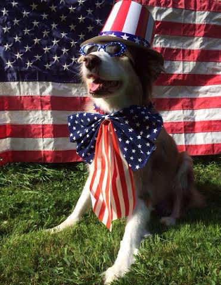

```python
Image(filename = "numerator_winner.jpg")
```

Fortunately we have our numenator winner. His name is Atticus.

#### Insight 3 - Most popular words with real information

```python
# source: https://stackoverflow.com/questions/46786211/counting-the-frequency-of-words-in-a-pandas-data-frame
# fint the most frequent words in the texts
clean_df['text'].str.split(expand=True).stack().value_counts()[:50]
```

```
is        1498
This      1247
a         1113
to         696
the        642
12/10      493
He's       491
He         453
would      430
10/10      429
11/10      418
for        363
of         346
in         327
13/10      302
and        244
his        242
Meet       216
this       194
just       183
on         179
be         179
you        175
pet        174
with       174
I          172
pupper     161
af         158
but        151
She        150
9/10       148
She's      148
af.        141
dog        138
that       137
an         126
he         125
at         122
very       118
not        114
good       113
her        111
by         111
your       110
it         108
all        108
only       105
as         104
was        104
like       103
dtype: int64
```

I wanted to see the most popular words with real information. So I didn't consider personal pronouns, articles, conjunctions and other words needed to build a sentence. I wanted only words with contextual meaning. The most used words with contextual meaning are: meet (216), pet (174), pupper (161) and dog (138). 3 from the first 4 is a kind of "dog word".

### Visualize Data

```python
# build dataframe with dog breeds and breed counts
breed_counts_df = clean_df['p1'].value_counts()[:20].rename_axis('unique_values').reset_index(name='counts')
```

```
Text(0.5,1,'Dog Breed Counts by the most likely predictions')
```

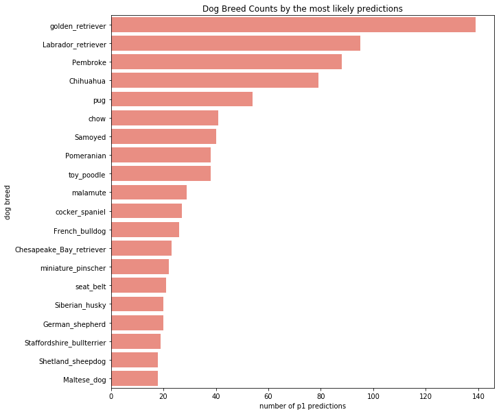

```python
# setup the barplot
f, ax = plt.subplots(figsize=(10, 10))
ax = sns.barplot(x="counts", y="unique_values", data=breed_counts_df, color="salmon")
ax.set_xlabel("number of p1 predictions")
ax.set_ylabel("dog breed")
ax.set_title("Dog Breed Counts by the most likely predictions")
```

In the above image we can see the the most popular dog breeds by occurrence according to the image predictions p1 (most probable) guess.

```
Text(0.5,1,'Scatterplot of retweet count and favorite count with log scale')
```

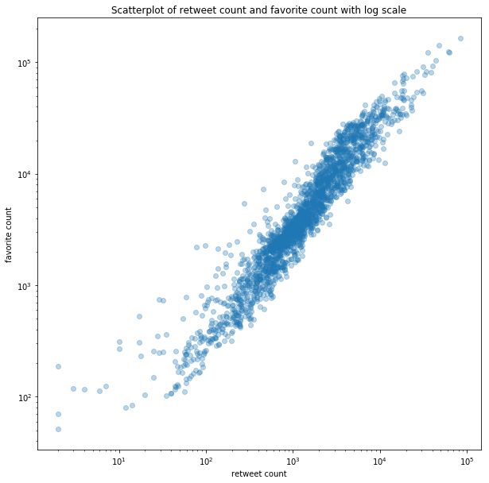

```python
f, ax = plt.subplots(figsize=(10, 10))
ax.set_yscale('log')
ax.set_xscale('log')
plt.scatter(clean_df["retweet_count"], clean_df["favorite_count"], alpha=0.3)
ax.set_xlabel("retweet count")
ax.set_ylabel("favorite count")
ax.set_title("Scatterplot of retweet count and favorite count with log scale")
```

In the plot above we can see that as the larger the retweet count of a dog the larger the favorite count most of the time.